# DATA 624 Homework 1 - Time Series

Monu Chacko

2/14/2021

```r
library(fpp)
library(fpp2)
library(ggplot2)
library(kableExtra)
```

## Question 2.1

Use the help function to explore what the series gold, woolyrnq and gas represent.

- Use autoplot() to plot each of these in separate plots.
- What is the frequency of each series? Hint: apply the frequency() function.
- Use which.max() to spot the outlier in the gold series. Which observation was it?

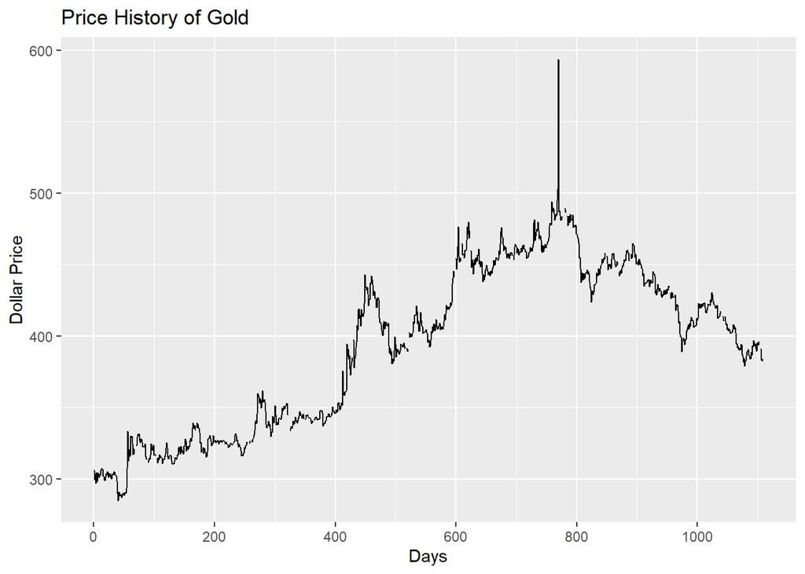

```r
autoplot(gold) + labs(title="Price History of Gold", x="Days", y="Dollar Price")
```

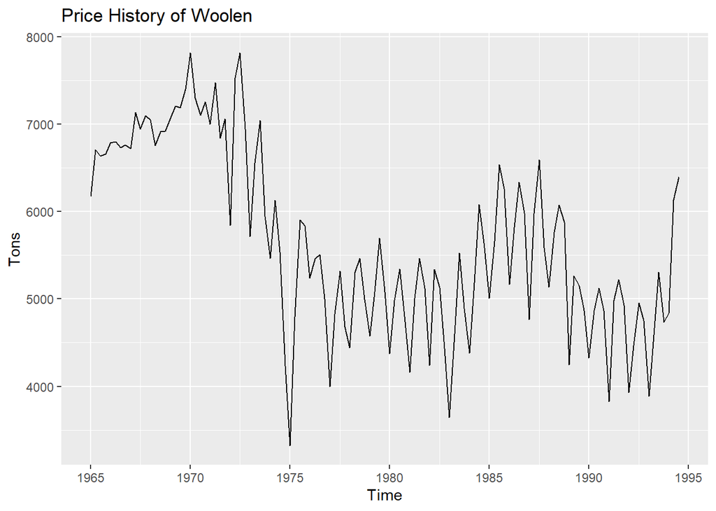

```r
autoplot(woolyrnq) + labs(title="Price History of Woolen", y="Tons")
```

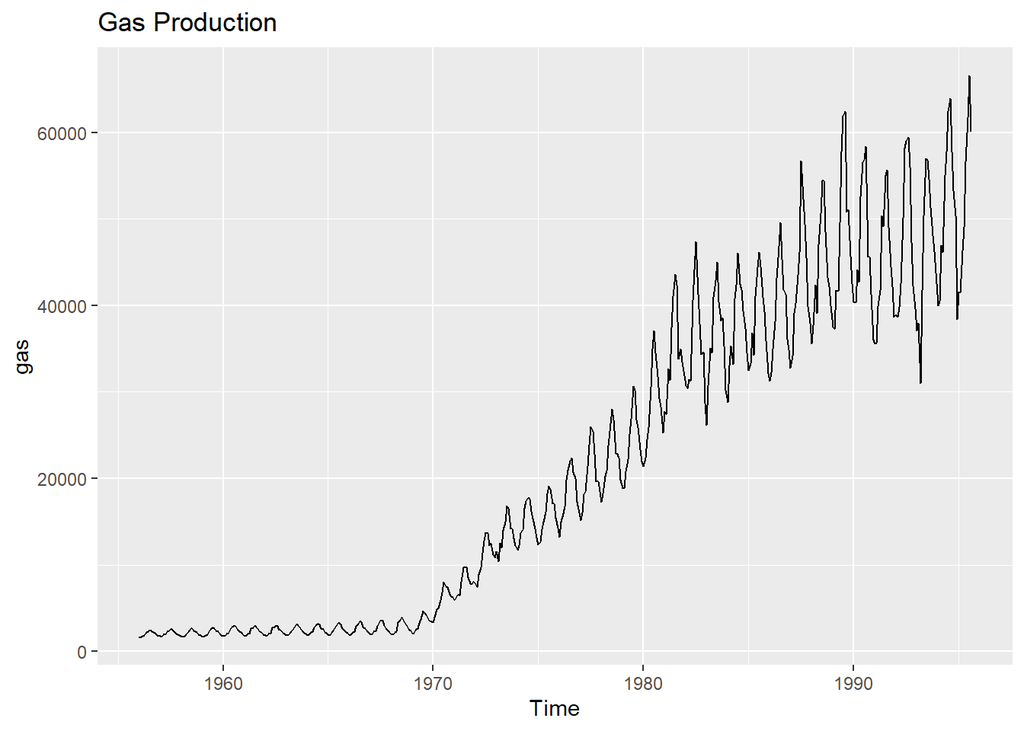

```r
autoplot(gas) + labs(title="Gas Production")
```

**Frequency (Gold)**

```r
frequency(gold)
```

```
## [1] 1
```

**Frequency (Woolen)**

```r
frequency(woolyrnq)
```

```
## [1] 4
```

**Frequency (Gas)**

```r
frequency(gas)
```

```
## [1] 12
```

**Outlier in the gold series**

```r
o_g <- which.max(gold)
paste0("The observation# ", o_g, " is an outlier")
```

```
## [1] "The observation# 770 is an outlier"
```

```r
paste0("Gold price was: ", gold[o_g])
```

```
## [1] "Gold price was: 593.7"
```